# P153146_Test2

```r
library(tuneR)
library(seewave)
```

```r
plot.frequency.spectrum <- function(X.k, xlimits = c(0,length(X.k))) {
  plot.data <- cbind(0:(length(X.k)-1),Mod(X.k))
  plot.data[2:length(X.k),2] <- 2*plot.data[2:length(X.k),2]

  plot(plot.data, t='h', lwd=2, main = '',
     xlab = 'Frequency (Hz)', ylab = "Strength",
     xlim = xlimits, ylim = c(0,max(Mod(plot.data[,2]))))
}
```

# Load the audio file

```r
audio <- readWave("audio.wav")
# play(audio)
```

```r
samp.rate <- audio@samp.rate
samp.rate
```

```
## [1] 44100
```

# Plot the audio using a function named timer() of R script. Briefly explain the plot.

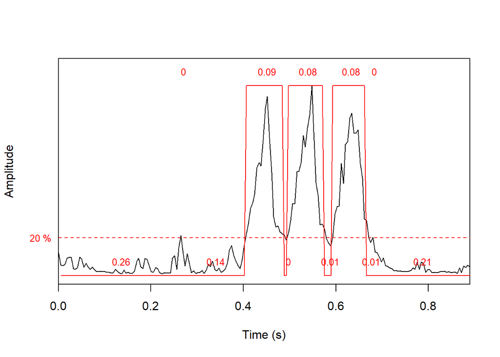

```r
timer(audio,f=samp.rate, threshold=20, msmooth=c(200,0))
```

From the timer plot above, it can be seen that the audio signal has a duration of approximately 1 second. The x-axis represents time in seconds, while the y-axis shows the amplitude of the audio signal. The plot indicates that there are 3 identifiable peaks in amplitude between 0.4s to 0.7s, suggesting moments of higher intensity in the audio. The threshold parameter helps to filter out lower amplitude noise, allowing us to focus on significant events in the audio. For this audio set a threshold of 20% and msmooth parameter of c(200,0) was used to smooth the plot, which helps in isolating the 3 peaks identified in the audio signal. It can be seen that there are 3 distinct sounds each lasting approximately 0.09 to 0.08 seconds with a gap of approximately 0.01 seconds between them.